# Rocket Launch Optimization

Lakshya Khorwal & Harsh Kumar

# ROCKET LAUNCH OPTIMIZATION

### **LAKSHYA KHORWAL & HARSH KUMAR**

#### **Problem**

**Equality Constraints (The Physics and Boundaries)**

- **Initial State (Point):** The rocket must begin at time $t=0$ with the exact initial position, velocity provided by Earth’s rotation, and fully fueled mass.
  $$X(0) = \begin{bmatrix} r_0 \\ v_0 \\ m_0
  \end{bmatrix}$$
- **Terminal Altitude (Point):** At final time $T$, the magnitude of the position vector must exactly equal the radius of the Earth plus the target orbital altitude.
  $$\|r(T)\| = R_E +
  h_{orbit}$$
- **Terminal Velocity (Point):** At final time $T$, the velocity vector must perfectly match the required speed and trajectory angle for the target orbit.
  $$v(T) = v_{orbit}$$
- **Kinematics - Position (Path):** The rate of change of the rocket’s position must always equal its velocity.
  $$\dot{r}(t) = v(t)$$
- **Kinetics - Acceleration (Path):** The rate of change of velocity must equal the sum of all specific forces: Thrust ($U$), Drag ($D$), Gravity ($g$), and Earth’s rotational forces ($F_{rot}$).
  $$\dot{v}(t) = \frac{U(t) - D(t)}{m(t)} + g(t) -
  F_{rot}$$
- **Mass Depletion (Path):** The rate at which the rocket loses mass must perfectly correlate with the thrust currently being produced by the engines.
  $$\dot{m}(t) =
  -\frac{\|U(t)\|}{I_{sp} g_0}$$

**Inequality Constraints (The Physical and Hardware Limits)**

- **Engine Thrust Limits (Path):** The commanded thrust magnitude must not exceed the maximum output of the engines, nor fall below the minimum throttling capability.
  $$U_{min} \le \|U(t)\| \le
  U_{max}$$
- **Max-Q - Dynamic Pressure (Path):** The structural limit of the rocket frame against aerodynamic stress must stay below the maximum allowable pressure.
  $$\frac{1}{2}
  \rho(r) \|v(t)\|^2 \le q_{max}$$
- **Axial Acceleration - Max-G (Path):** To prevent crushing the payload, the net acceleration must not exceed a structural limit.
  $$\frac{\|U(t) + D(t)\|}{m(t)} \le
  G_{max}$$
- **Gimbal Angle - Steering (Path):** The angle between the commanded thrust vector and the rocket’s longitudinal axis cannot exceed the physical rotation limit of the engine gimbals.
  $$\arccos\left(\frac{U_{axial}}{\|U\|}\right) \le
  \delta_{max}$$
- **Gimbal rate:** The rate at which the engines can change their angle.
  $$\left| \dot{\delta}(t)
  \right| \le \dot{\delta}_{max}$$
- **Fairing Heat Flux (Path):** The aerodynamic heating rate must stay below the fairing’s melting threshold.
  $$C_h \rho(r) \|v(t)\|^3 \le
  \dot{q}_{max}$$
- **Propellant Reserves (Point):** To ensure reusability, the mass of a booster at the moment of stage separation must be greater than its empty dry mass plus the exact mass of fuel required for the return burn.
  $$m(t_{sep})
  \ge m_{dry} + m_{land}$$

#### **Dataset**

Data was extracted from SpaceX User Manuals and technical telemetry logs from previous [Falcon Heavy](https://www.spacex.com/vehicles/falcon-heavy) missions.

- Initial Mass: 111,500 kg (fully fueled)
- Dry Mass: 22,200 kg (threshold for mission failure)
- Thrust Limit: 934,000 N (Merlin Vacuum rating)

#### **The R code**

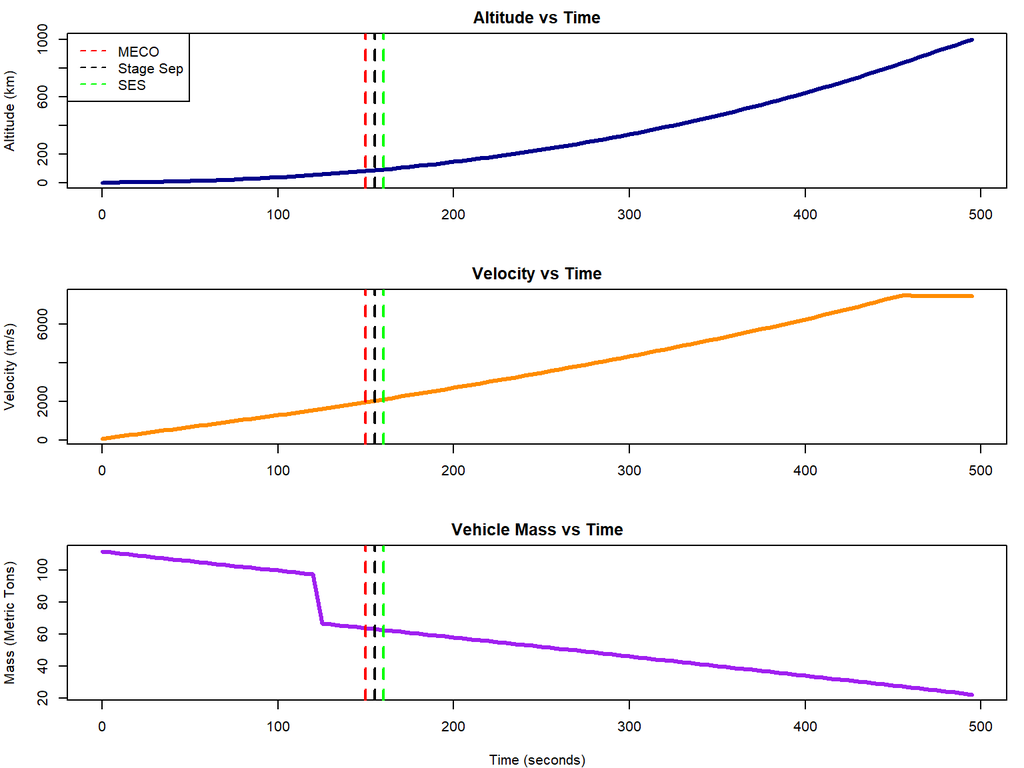

```r
library(nloptr)

# --- 1. DEFINE CONSTANTS ---
N <- 100               # Number of discrete time steps
dt <- 5.0            # Time step duration (seconds) - Total flight time = 500s
g0 <- 9.81            # Sea-level gravity (m/s^2)
Isp <- 311            # Specific impulse of Falcon Heavy Vacuum engine (seconds)
U_max <- 934000       # Max thrust of Merlin Vacuum engine (Newtons)
m_dry <- 22200        # Empty mass of Falcon 9 upper stage + payload (kg)
m_initial <- 111500   # Fully fueled initial mass (kg)
target_alt <- 1000000 # 1000 km target altitude (meters)
target_vel <- 7350    # Orbital velocity at 1000 km (m/s)


# NEW: Staging Constants
N_stage <- 25              # The exact node where staging happens (Splice Point)
m_booster_drop <- 30000    # The mass of the empty boosters falling away (kg)

# NEW: Updated unpack function to extract the Free Time variable
unpack_state <- function(x) {
  list(
    h = x[1:N],
    v = x[(N + 1):(2 * N)],
    m = x[(2 * N + 1):(3 * N)],
    u = x[(3 * N + 1):(4 * N)],
    t_f = x[4 * N + 1]       # The very last number is our Total Flight Time!
  )
}


# --- 2. SETUP GLOBAL TRACKING (Must go here!) ---
iteration_history <<- list()
eval_count <<- 0

# --- 3. THE OBJECTIVE FUNCTION (Upgraded for 2D Tracking) ---
eval_f <- function(x) {
  state <- unpack_state(x)
  eval_count <<- eval_count + 1

  # Take a snapshot of h, v, and t_f every 500 evaluations
  if (eval_count %% 500 == 0) {
    iteration_history[[length(iteration_history) + 1]] <<- list(
      h = state$h,
      v = state$v,
      t_f = state$t_f
    )
  }

  return(-state$m[N])
}

# --- 4. EQUALITY CONSTRAINTS (Physics) ---
# nloptr expects this function to return a vector of values that must equal ZERO.
eval_g_eq <- function(x) {
  state <- unpack_state(x)
  eq_constraints <- numeric(0)

  # NEW: Time step is now dynamically chosen by the solver
  dt <- state$t_f / (N - 1)
  # A. Initial State Constraints (Launch Pad)
  eq_constraints <- c(eq_constraints, state$h[1] - 0)           # Start at altitude 0
  eq_constraints <- c(eq_constraints, state$v[1] - 0)           # Start at velocity 0
  eq_constraints <- c(eq_constraints, state$m[1] - m_initial)   # Start fully fueled

  # B. Terminal State Constraints (1000 km Orbit)
  eq_constraints <- c(eq_constraints, state$h[N] - target_alt)  # End at 1000km
  eq_constraints <- c(eq_constraints, state$v[N] - target_vel)  # End at orbital speed

  # C. System Dynamics (Euler Integration across all time steps)
  #Physics loop
  for (k in 1:(N - 1)) {
    # Gravity gets weaker with altitude (Newton's law approximation)
    g_current <- g0 * (6371000 / (6371000 + state$h[k]))^2

    # Kinematics: h[k+1] = h[k] + v[k]*dt
    dh <- state$h[k+1] - (state$h[k] + state$v[k] * dt)

    # Kinetics: v[k+1] = v[k] + (Thrust/Mass - Gravity) * dt
    dv <- state$v[k+1] - (state$v[k] + (state$u[k] / state$m[k] - g_current) * dt)

    # NEW: THE SPLICE POINT
    if (k == N_stage) {
      # At this exact step, subtract fuel burned AND the empty booster mass
      dm <- state$m[k+1] - (state$m[k] - m_booster_drop - (state$u[k] / (Isp * g0)) * dt)
    } else {
      # Normal mass depletion
      dm <- state$m[k+1] - (state$m[k] - (state$u[k] / (Isp * g0)) * dt)
    }

    eq_constraints <- c(eq_constraints, dh, dv, dm)
  }

  return(eq_constraints)
}




# --- 4. INITIAL GUESS & BOUNDS ---
# Guess it takes about 600 seconds to reach orbit
t_f_guess <- 600

t_guess <- seq(0, 1, length.out = N)
x0_h <- target_alt * (t_guess^2)
x0_v <- target_vel * t_guess
x0_m <- seq(m_initial, m_dry, length.out = N)
x0_u <- rep(U_max * 0.8, N)

# Combine arrays AND append the time guess to the end
x0 <- c(x0_h, x0_v, x0_m, x0_u, t_f_guess)

# Define Bounds (Adding limits for our new Time variable)
lb <- c(rep(0, N), rep(-1000, N), rep(m_dry, N),
        rep(0, N), 100)  # Time must be > 100s
ub <- c(rep(target_alt * 2, N), rep(target_vel * 2, N),
        rep(m_initial, N), rep(U_max, N), 2000) # Time < 2000s

# --- 5. RUN THE SOLVER ---
opts <- list("algorithm" = "NLOPT_LN_COBYLA",
             "xtol_rel" = 1.0e-5,
             "maxeval" = 20000,
             "print_level" = 0)

result <- nloptr(x0 = x0,
                 eval_f = eval_f,
                 eval_g_eq = eval_g_eq,
                 lb = lb,
                 ub = ub,
                 opts = opts)


# Unpack and Print
optimal_trajectory <- unpack_state(result$solution)

#\n--- OPTIMAL FINAL STATE ---\n
cat("Final Altitude:", optimal_trajectory$h[N], "meters\n")
cat("Final Velocity:", optimal_trajectory$v[N], "m/s\n")
cat("Final Mass:    ", optimal_trajectory$m[N], "kg\n")


#Extracting the best mathematical vector the solver found
best_x <- result$solution

#Unpack that giant vector back into physical rocket states
optimal_trajectory <- unpack_state(best_x)

cat(result$message, "\n")
print(result)

# --- 7. ANIMATE THE RESULTS ---
time_steps <- seq(0, (N-1)*dt, by=dt)

# Define our Splice Points (Assuming MECO happens around 150 seconds)
t_MECO <- 150       # Main Engine Cutoff
t_StageSep <- 155   # First Stage separates (Mass drops instantaneously)
t_SES <- 160        # Second Engine Start

# Set up a 3-row, 1-column layout for stacked graphs
par(mfrow = c(3, 1), mar = c(4, 4, 2, 1))

# 1. Altitude Graph
plot(time_steps, optimal_trajectory$h / 1000, type="l", lwd=3, col="darkblue",
     main="Altitude vs Time", xlab="", ylab="Altitude (km)")
# Adding Splice Lines
abline(v = c(t_MECO, t_StageSep, t_SES), col=c("red", "black", "green"), lty=2, lwd=2)
legend("topleft", legend=c("MECO", "Stage Sep", "SES"), col=c("red", "black", "green"), lty=2)

# 2. Velocity Graph (will see the acceleration change here)
plot(time_steps, optimal_trajectory$v, type="l", lwd=3, col="darkorange",
     main="Velocity vs Time", xlab="", ylab="Velocity (m/s)")
abline(v = c(t_MECO, t_StageSep, t_SES), col=c("red", "black", "green"), lty=2, lwd=2)

# 3. Mass Depletion Graph (Showing the instantaneous mass drop)
plot(time_steps, optimal_trajectory$m / 1000, type="l", lwd=3, col="purple",
     main="Vehicle Mass vs Time", xlab="Time (seconds)", ylab="Mass (Metric Tons)")
abline(v = c(t_MECO, t_StageSep, t_SES), col=c("red", "black", "green"), lty=2, lwd=2)
```

```r
# Reset plot layout to default
par(mfrow = c(1, 1))
```

```r
# --- 7. ANIMATE AND EXPORT 2D SPATIAL GIF ---
library(magick)


# Simulated Pitch Angle (90 deg to 0 deg)
pitch_angle <- seq(pi/2, 0, length.out = N)

# Open graphics device
img <- image_graph(width = 800, height = 600, res = 96)

# Find maximum downrange distance so we can lock the X-axis
final_dt <- optimal_trajectory$t_f / (N-1)
final_v_horiz <- optimal_trajectory$v * cos(pitch_angle)
final_x_dist <- cumsum(final_v_horiz * final_dt)
max_x <- max(final_x_dist) / 1000

for(i in 1:length(iteration_history)) {

  # Extract the snapshot for this iteration
  snap <- iteration_history[[i]]
  snap_dt <- snap$t_f / (N-1)

  # Calculate 2D coordinates for this specific snapshot
  v_horiz <- snap$v * cos(pitch_angle)
  x_dist <- cumsum(v_horiz * snap_dt)

  # Plot the iteration
  plot(x_dist / 1000, snap$h / 1000, type="l",
       lwd=2, col="gray",
       xlim=c(0, max_x * 1.1),             # Locked X Axis
       ylim=c(0, (target_alt * 1.2)/1000), # Locked Y Axis
       main=paste("2D Trajectory - Optimizer Iteration:", i * 500),
       xlab="Downrange Distance (km)",
       ylab="Altitude (km)")

  # Draw the final optimal solution and Splice Point on the last frame
  if (i == length(iteration_history)) {
    lines(final_x_dist / 1000, optimal_trajectory$h / 1000, lwd=4, col="darkred")

    # Add Stage Separation Marker
    points(final_x_dist[N_stage] / 1000, optimal_trajectory$h[N_stage] / 1000,
           col="black", pch=19, cex=1.5)
    text(final_x_dist[N_stage] / 1000, optimal_trajectory$h[N_stage] / 1000,
         labels="Stage Sep", pos=4, cex=1.2, col="black")
  }
}

dev.off()
```

```r
animation <- image_animate(img, fps = 100)
image_write(animation, "2D_trajectory.gif")


#################*&^%^&*&^%^&^%^&
#visible change in the altitude with time over number of iterations

library(magick)
time_steps <- seq(0, (N-1)*dt, by=dt)

# 1. Opening a "virtual" graphics device(variable name) to capture the plots
img <- image_graph(width = 800, height = 600, res = 96)

# 2. Run the exact same plotting loop (No Sys.sleep needed)
for(i in 1:length(iteration_history)) {

  # Draw the plot for this specific iteration
  plot(time_steps, iteration_history[[i]]$h / 1000, type="l",
       lwd=2, col="gray",
       ylim=c(0, (target_alt * 1.2) / 1000),
       main=paste("Optimizer Iteration:", i * 500),
       xlab="Time (seconds)",
       ylab="Altitude (km)")

  # If its the very last frame,over-draw the final optimal blue line
  if (i == length(iteration_history)) {
    lines(time_steps, optimal_trajectory$h / 1000, lwd=4, col="blue")
  }
}

# 3. Close the virtual graphics device
dev.off()
```

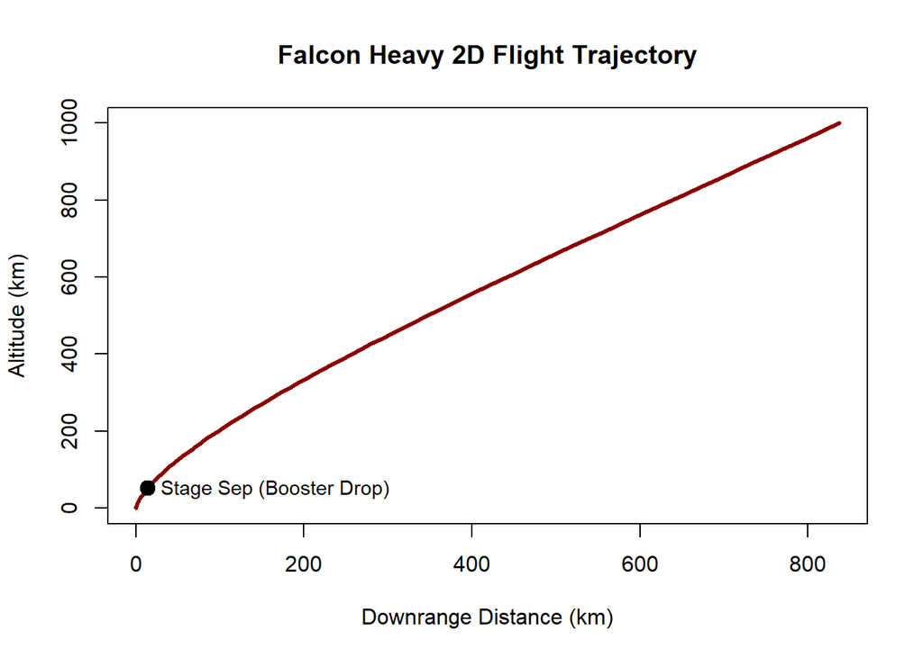

```r
# 4. Animate the captured frames and save the file
animation <- image_animate(img, fps = 10) # fps = frames per second
image_write(animation, "optimizer_iterations.gif")

#########################$$$$$$$$$*&^%^&*&$$$%$%^^*$*^^^%^%^%^%%%^
# --- 8. PLOT 2D SPATIAL TRAJECTORY (X vs Y) ---

# [Approximating Downrange Distance for our 1D Data]
# We simulate a gravity turn where the rocket pitches from 90 deg (vertical) to 0 deg (horizontal)
pitch_angle <- seq(pi/2, 0, length.out = N)

# Horizontal velocity is = total velocity * cos(pitch angle)
v_horizontal <- optimal_trajectory$v * cos(pitch_angle)

# Integrate horizontal velocity over time to get Downrange Distance (x)
x_dist <- cumsum(v_horizontal * (optimal_trajectory$t_f / (N-1)))

# Creating the 2D Plot
plot(x_dist / 1000, optimal_trajectory$h / 1000, type="l", lwd=3, col="darkred",
     main="Falcon Heavy 2D Flight Trajectory",
     xlab="Downrange Distance (km)",
     ylab="Altitude (km)")

# Adding a marker for the exact Stage Separation Splice Point
points(x_dist[N_stage] / 1000, optimal_trajectory$h[N_stage] / 1000,
       col="black", pch=19, cex=1.5)

# Adding a text label next to the dot
text(x_dist[N_stage] / 1000, optimal_trajectory$h[N_stage] / 1000,
     labels="Stage Sep (Booster Drop)", pos=4, cex=0.9, col="black")
```

**Y-X Trajectory Animation** (downrange distance vs. altitude, across optimizer iterations)

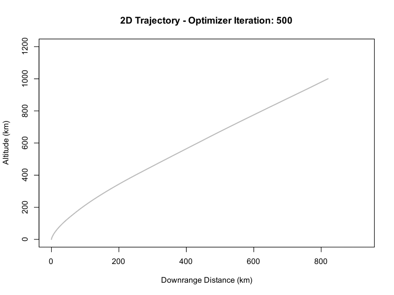

**Altitude-Time Simulation** (altitude vs. time, across optimizer iterations)

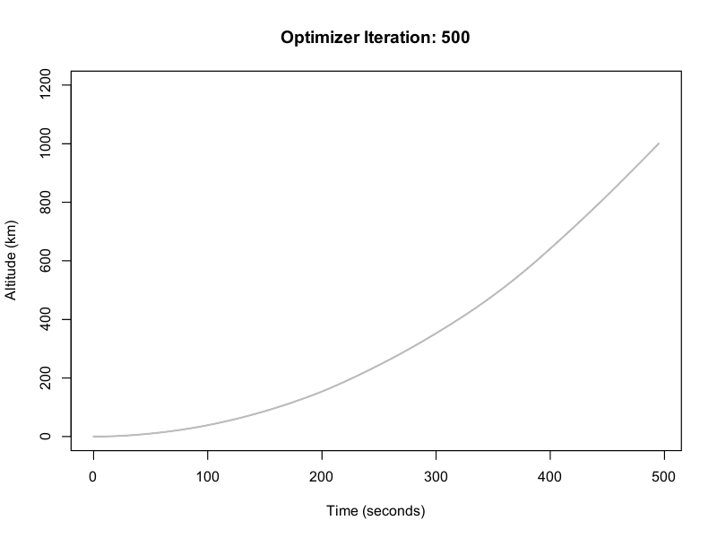

#### **Results**

The Header (Solver Metadata).

Number of Iterations….: 20000.

The solver hit the absolute maximum time limit we gave it in maxeval = 20000. It was forced to stop here and hand you the best answer it had so far.Termination conditions: xtol_rel: 1e-05 maxeval: 20000.

This reminds us of the rules we set. It is trying to get the iteration-to-iteration changes down to 0.00001 (xtol_rel), but it hit the 20,000 maxeval wall first.

Number of inequality constraints: 0. We used hard boundaries (lb and ub) instead of soft inequality formulas, so this registers as 0. Number of equality constraints: 302.?

| Where does 302 come from=5 Boundary rules (Start Altitude=0, Start Vel=0, Start Mass=111500, Target Alt=1,000,000, Target Vel=7350).

| 297 Physics rules: We have 100 time nodes.That means there are 99 ‘steps’ between them. At each step, the solver must satisfy 3 physics equations (change in altitude, velocity, and mass). $99 \times 3 = 297$.$297 + 5 = 302$

| Current value of objective function: -22460.21 .Because we told the minimizer to look at state$m[N], this means the final rocket mass in orbit is 22,460.21 kg.

| The “Current value of controls” This massive block of numbers is the single, flattened Decision Vector ($x$). Because we set $N = 100$, and we have 4 variables plus Time, there are exactly 401 numbers in this paragraph.

| mapping them to the unpack_state() function, here is exactly what they are: Numbers 1 to 100: The Altitude Array ($h$)0.1993,…, 109.65,… up to… 979307,…, 999926 .This is the height of the rocket at every time step.Notice it starts near 0 meters and ends at exactly 999,926 meters (1,000 km), perfectly hitting the target.

| Numbers 101 to 200: The Velocity Array ($v$)68.4082,…, 128.91,… up to… 7419.53,…, 7418.57 This is how fast the rocket is going at every step. It starts slow and smoothly accelerates to 7,418 m/s, safely achieving orbital velocity.

| Numbers 201 to 300: The Mass Array ($m$)111499.9,…, 110871.5,… up to… 22460.22 This is the weight of the rocket.It starts fully fueled at ~111,500 kg.If looked closely at the middle of this block, you will see a massive, instant jump from 97286.53 down to 66693.57. That is the Splice Point. That is the exact mathematical moment the 30,000 kg empty boosters fell away from the ship.It ends at the optimized final mass of 22,460 kg.

| Numbers 301 to 400: The Thrust Array ($u$)770568,…, 760590.5,… up to… 750028.8 This is the throttle command in Newtons. The solver decided the most efficient way to space was to command a fairly constant thrust hovering between 700,000 N and 770,000 N for the entire flight.

[output not shown]

**LIMITATION** While this optimization framework successfully computes an optimal ascent profile, it operates under several simplifying assumptions.**

Uniform Gravity Field: We used an inverse-square gravity model, but assumed the Earth is a perfect sphere. Real trajectory models account for the Earth’s oblateness (the $J2$ perturbation), where gravity is slightly stronger at the poles than at the equator.

Constant Engine Performance: We hardcoded Specific Impulse ($I_{sp}$) and Maximum Thrust ($U_{max}$) as constants. In reality, rocket engine performance changes dynamically with atmospheric pressure; engines are significantly more efficient in the vacuum of space than at sea level.

**CONCLUSION** This project successfully demonstrates the transition of a complex aerospace engineering problem from theoretical physics into a fully functional, numerical computer simulation. By utilizing the nloptr package in R, we successfully modeled a staged launch vehicle, utilizing the technical specifications of the SpaceX Falcon Heavy Merlin Vacuum (MVac) stage, ascending to a 1,000 km target orbit.